# Homework 8

## Exercise 1

```python
class Graph:

    def __init__(self, vertices_num):
        self.ids = {}
        self.adjacent = [[] for _ in range(vertices_num)]

    def add_edge(self, v1, v2):
        if v1 in self.adjacent[v2]:
            return
        self.adjacent[v1].append(v2)
        self.adjacent[v2].append(v1)

    def parse(self, file):
        # skip unnecessary first 4 lines
        for line in file.readlines()[4:]:
            edge = line.split()
            for v in edge:
                if v not in self.ids:
                    self.ids[v] = len(self.ids)

            self.add_edge(self.ids[edge[0]], self.ids[edge[1]])

    def degree(self, vertex):
        return len(self.adjacent[vertex])

    def size(self):
        return len(self.adjacent)

    def edges_num(self):
        return sum([len(lst) for lst in self.adjacent]) // 2
```

```python
import gzip
import requests
```

Let's download the archive for **High-energy physics citation network**.

Arxiv HEP-PH (high energy physics phenomenology ) citation graph is from the e-print arXiv and covers all the citations within a dataset of 34,546 papers with 421,578 edges. If a paper i cites paper j, the graph contains a directed edge from i to j. If a paper cites, or is cited by, a paper outside the dataset, the graph does not contain any information about this.

```python
with open('citations.gz', 'wb') as file:
    file.write(requests.get('https://snap.stanford.edu/data/cit-HepPh.txt.gz').content)
```

Let's download the archive for **Google web graph**.

Nodes represent web pages and directed edges represent hyperlinks between them. The data was released in 2002 by Google as a part of Google Programming Contest.

```python
with open('googleweb.gz', 'wb') as file:
    file.write(requests.get('https://snap.stanford.edu/data/web-Google.txt.gz').content)
```

Let's parse the graphs into the respective class instances and analyze them.

```python
import matplotlib.pyplot as plt
import numpy as np
```

```python
def plot_degree_hist(degrees, bins, range_, title, color):
    plt.rcParams["figure.figsize"] = (12, 8)
    plt.xlabel('vertex degree')
    plt.ylabel('number of vertices')
    plt.title(title)
    plt.hist(degrees, bins, range_, color=color)

    plt.show()
```

```python
citations_graph = Graph(34546)

with gzip.open('citations.gz','r') as file:
    citations_graph.parse(file)

print(f"Number of nodes: {citations_graph.size()}")
print(f"Number of edges: {citations_graph.edges_num()}")
```

```
Number of nodes: 34546
Number of edges: 420921
```

Typically dense graphs have a quadratic number of edges. The actual number of edges in the graph is much less than $|V|^2$ and about 10 times greater than the number of nodes. Therefore we can't call the graph dense, it is rather sparse. This means, by the way, the the chosen graph representation as an adjacency list suits the nature of the graph well.

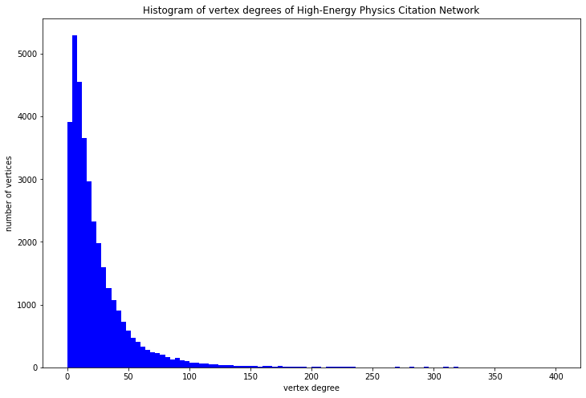

```python
degrees = [citations_graph.degree(i) for i in range(citations_graph.size())]
plot_degree_hist(degrees, 100, (0, 400), "Histogram of vertex degrees of High-Energy Physics Citation Network", 'blue')
```

From the histogram, we may conclude that most of the nodes (papers) have just a few outgoing edges (citations). Node degrees (number of citations) subside exponentially.

```python
web_graph = Graph(875713)

with gzip.open('googleweb.gz','r') as file:
    web_graph.parse(file)

print(f"Number of nodes: {web_graph.size()}")
print(f"Number of edges: {web_graph.edges_num()}")
```

```
Number of nodes: 875713
Number of edges: 4322051
```

Typically dense graphs have a quadratic number of edges. The actual number of edges in the graph is much less than $|V|^2$ and about 5 times greater than the number of nodes. Therefore we can't call the graph dense, it is rather sparse. This means, by the way, the the chosen graph representation as an adjacency list suits the nature of the graph well.

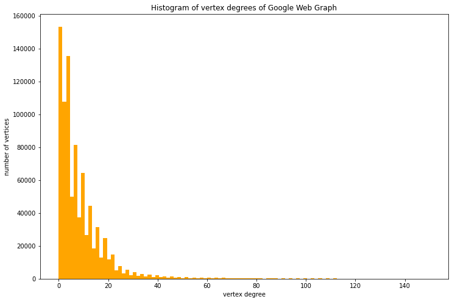

```python
degrees = [web_graph.degree(i) for i in range(web_graph.size())]
plot_degree_hist(degrees, 100, (0, 150), "Histogram of vertex degrees of Google Web Graph", 'orange')
```

From the histogram, we may conclude that most of the nodes (webpages) have just a few outgoing edges (hyperlinks). Node degrees (number of hyperlinks) subside exponentially.

## Exercise 2

```python
import bisect
import urllib

from collections import deque
```

```python
class AnotherGraph:

    def __init__(self):
        self.coordinates = []
        self.adjacent = []

    def add_edge(self, v1, v2):
        if v1 in self.adjacent[v2]:
            return
        bisect.insort(self.adjacent[v1], v2)
        bisect.insort(self.adjacent[v2], v1)

    def parse(self, file):
        is_vertex = True

        for line in file.readlines():
            line = line.split()
            line = [string.decode('utf-8') for string in line]

            if len(line) == 0 or line[0] == 'VERTICES':
                continue

            if line[0] == 'EDGES':
                is_vertex = False
                continue

            if is_vertex:
                v = int(line[0])
                x = int(line[1])
                y = int(line[2])
                self.adjacent.append([])
                self.coordinates.append((x, y))
            else:
                self.add_edge(int(line[0]), int(line[1]))

    def size(self):
        return len(self.adjacent)

    def neighbours(self, vertex):
        return self.adjacent[vertex]
```

```python
def BFS(graph):
    result = []
    used = [False] * graph.size()
    queue = deque([0])
    used[0] = True

    while len(queue) != 0:
        v = queue.popleft()
        result.append(v)

        adjacent = graph.neighbours(v)
        for a in adjacent:
            if not used[a]:
                queue.append(a)
                used[a] = True

    return result
```

```python
def DFS(graph):
    result = []
    used = [False] * graph.size()
    stack = deque([0])

    while len(stack) != 0:
        v = stack.pop()

        if used[v]:
            continue

        result.append(v)
        used[v] = True

        adjacent = graph.neighbours(v)
        for i in range(len(adjacent) - 1, -1, -1):
            a = adjacent[i]
            if not used[a]:
                stack.append(a)

    return result
```

```python
graph = AnotherGraph()
url = 'https://courses.cs.ut.ee/MTAT.03.238/2020_fall/uploads/Main/dataset_bfsdfs.txt'

with urllib.request.urlopen(url) as file:
    graph.parse(file)

print(graph.size())
```

```
34
```

```python
print(BFS(graph))
```

```
[0, 1, 2, 3, 4, 5, 6, 7, 8, 10, 11, 12, 13, 17, 19, 21, 31, 30, 9, 27, 28, 32, 16, 33, 24, 25, 23, 14, 15, 18, 20, 22, 29, 26]
```

```python
print(DFS(graph))
```

```
[0, 1, 2, 3, 7, 12, 13, 33, 8, 30, 32, 14, 15, 18, 20, 22, 23, 25, 24, 27, 31, 28, 29, 26, 9, 19, 17, 21, 4, 6, 5, 10, 16, 11]
```

Let's use [graph visualisation code](https://github.com/PuuraJ/AdvancedAlgorithmics/blob/master/graph_task_visualiser.py) to generate input for [graph visualisation tool](https://abercus.github.io/searchvis/).

```python
### Drawing parameters ###
# Edge width and color
edge_width = 1
edge_color = "blue"

# Node radius and color
node_radius = 15
node_color = "black"

# Text size and color
text_color = "orange"
text_size = 18

# Traversal text size and color
trav_color = "darkred"
trav_size = 18

# Create edges input for tool
for i in range(len(graph.adjacent)):
    for j in graph.adjacent[i]:
        print(f"line {graph.coordinates[i][0]} {graph.coordinates[i][1]}"\
              f" {graph.coordinates[j][0]} {graph.coordinates[j][1]} {edge_width} {edge_color}")


# Create vertices input for tool
for i in range(len(graph.adjacent)):
    print(f"circle {graph.coordinates[i][0]} {graph.coordinates[i][1]} {node_radius} {node_color}")

# Add text on top of vertices
for i in range(len(graph.adjacent)):
    print(f'text "{i}" {graph.coordinates[i][0]-8} {graph.coordinates[i][1]+8} {text_size} {text_color}')

# Add order of traversal
bfs = [0, 1, 2, 3, 4, 5, 6, 7, 8, 10, 11, 12, 13, 17, 19, 21, 31, 30, 9, 27, 28, 32, 16, 33, 24, 25, 23,
       14, 15, 18, 20, 22, 29, 26]
dfs = [0, 1, 2, 3, 7, 12, 13, 33, 8, 30, 32, 14, 15, 18, 20, 22, 23, 25, 24, 27, 31, 28, 29, 26, 9, 19,
       17, 21, 4, 6, 5, 10, 16, 11]

# i is the order #, k is the vertex id.
for i, k in enumerate(dfs):
    print(f'text "{i}" {graph.coordinates[k][0]+18} {graph.coordinates[k][1]+8} {trav_size} {trav_color}')
```

```
line 652 396 742 479 1 blue
line 652 396 502 536 1 blue
line 652 396 462 411 1 blue
line 652 396 896 298 1 blue
line 652 396 617 198 1 blue
line 652 396 756 212 1 blue
line 652 396 539 372 1 blue
line 652 396 660 603 1 blue
line 652 396 769 267 1 blue
line 652 396 478 222 1 blue
line 652 396 390 272 1 blue
line 652 396 616 548 1 blue
line 652 396 950 450 1 blue
line 652 396 753 592 1 blue
line 652 396 921 390 1 blue
line 652 396 402 536 1 blue
line 742 479 652 396 1 blue
line 742 479 502 536 1 blue
line 742 479 462 411 1 blue
line 742 479 539 372 1 blue
line 742 479 616 548 1 blue
line 742 479 950 450 1 blue
line 742 479 753 592 1 blue
line 742 479 921 390 1 blue
line 742 479 764 691 1 blue
line 502 536 652 396 1 blue
line 502 536 742 479 1 blue
line 502 536 462 411 1 blue
line 502 536 539 372 1 blue
line 502 536 660 603 1 blue
line 502 536 372 671 1 blue
line 502 536 616 548 1 blue
line 502 536 260 626 1 blue
line 502 536 315 605 1 blue
line 502 536 542 744 1 blue
line 462 411 652 396 1 blue
line 462 411 742 479 1 blue
line 462 411 502 536 1 blue
line 462 411 539 372 1 blue
line 462 411 390 272 1 blue
```

[output cut: 203 more lines]

```
text "19" 278 634 18 darkred
text "20" 420 544 18 darkred
text "21" 333 613 18 darkred
text "22" 369 870 18 darkred
text "23" 514 958 18 darkred
text "24" 390 679 18 darkred
text "25" 771 600 18 darkred
text "26" 968 458 18 darkred
text "27" 939 398 18 darkred
text "28" 914 306 18 darkred
text "29" 774 220 18 darkred
text "30" 635 206 18 darkred
text "31" 787 275 18 darkred
text "32" 757 48 18 darkred
text "33" 496 230 18 darkred
```

| BFS |
| --- |

| DFS |
| --- |

## Exercise 3

[figure not shown]

The task requires connecting "only vertices that are reachable in 3 steps of [sic] the original graph". Let's interpret that as connecting vertices with every vertex that can be reached from the current one **precisely** in 3 steps (vertices repetition allowed).

```python
class DirectedGraph:

    def __init__(self, vertices, matrix):
        self.vertices = vertices
        self.adjacent = [[] for _ in range(len(matrix))]

        for i in range(len(matrix)):
            for j in range(len(matrix)):
                if i != j and matrix[i][j]:
                    self.adjacent[i].append(j)

    def __repr__(self):
        string = ''

        for i in range(len(self.adjacent)):
            string += f"{self.vertices[i]}: {', '.join([self.vertices[j] for j in self.adjacent[i]])}\n"

        return string
```

```python
def threehop(matrix):
    result = [[False] * len(matrix) for _ in range(len(matrix))]
    for i in range(len(matrix)):
        threehop_recursive(i, i, 1, matrix, result)
    return result


def threehop_recursive(from_, to_, depth, original, result):
    for i in range(len(original)):
        if i != to_ and original[to_][i]:
            if depth == 3:
                result[from_][i] = True
            else:
                threehop_recursive(from_, i, depth + 1, original, result)
```

Let's convert the given picture into adjacency matrix by hand, build a graph by the matrix and display it.

```python
vertices = ['A', 'B', 'C', 'D', 'E', 'F', 'G', 'H', 'I', 'J', 'K']
matrix = [[1, 1, 0, 0, 0, 1, 0, 0, 0, 0, 0],
         [0, 1, 0, 0, 0, 0, 0, 0, 0, 0, 0],
         [0, 1, 1, 0, 1, 0, 1, 0, 0, 0, 0],
         [0, 0, 1, 1, 0, 0, 0, 0, 0, 0, 0],
         [0, 0, 0, 0, 1, 0, 0, 1, 0, 0, 1],
         [0, 0, 0, 0, 1, 1, 0, 0, 0, 0, 0],
         [0, 0, 0, 0, 1, 0, 1, 0, 0, 1, 0],
         [0, 0, 0, 0, 0, 1, 0, 1, 0, 0, 0],
         [0, 0, 0, 0, 0, 0, 1, 0, 1, 0, 0],
         [0, 0, 0, 0, 0, 0, 0, 0, 1, 1, 0],
         [0, 0, 0, 0, 1, 0, 0, 0, 0, 0, 1]]
```

```python
graph = DirectedGraph(vertices, matrix)
print(graph)
```

```
A: B, F
B:
C: B, E, G
D: C
E: H, K
F: E
G: E, J
H: F
I: G
J: I
K: E
```

The graph is correct.

Let's do the 3-hop modification.

```python
modified = threehop(matrix)
new_graph = DirectedGraph(vertices, modified)
print(new_graph)
```

```
A: H, K
B:
C: E, F, H, I, K
D: E, H, J, K
E: H, K
F: E
G: E, F
H: K
I: H, K
J: E
K: E, F
```

## Exercise 4

```python
def copy_matrix(matrix):
    result = [[False] * len(matrix) for _ in range(len(matrix))]
    for i in range(len(matrix)):
        for j in range(len(matrix)):
            result[i][j] = matrix[i][j]
    return result
```

```python
def closure_by_powering(matrix):
    result = copy_matrix(matrix)

    result = np.linalg.matrix_power(result, len(result))

    for i in range(len(result)):
        for j in range(len(result)):
            result[i][j] = result[i][j] > 0

    return result
```

```python
def floyd_warshall(matrix):
    result = copy_matrix(matrix)

    for k in range(len(result)):
        for i in range(len(result)):
            for j in range(len(result)):
                result[i][j] = result[i][j] or (result[i][k] and result[k][j])

    return result
```

```python
powering_result = closure_by_powering(matrix)
print('\n'.join(str(row) for row in powering_result))

powering_graph = DirectedGraph(vertices, powering_result)
print()
print(powering_graph)
```

```
[1 1 0 0 1 1 0 1 0 0 1]
[0 1 0 0 0 0 0 0 0 0 0]
[0 1 1 0 1 1 1 1 1 1 1]
[0 1 1 1 1 1 1 1 1 1 1]
[0 0 0 0 1 1 0 1 0 0 1]
[0 0 0 0 1 1 0 1 0 0 1]
[0 0 0 0 1 1 1 1 1 1 1]
[0 0 0 0 1 1 0 1 0 0 1]
[0 0 0 0 1 1 1 1 1 1 1]
[0 0 0 0 1 1 1 1 1 1 1]
[0 0 0 0 1 1 0 1 0 0 1]

A: B, E, F, H, K
B:
C: B, E, F, G, H, I, J, K
D: B, C, E, F, G, H, I, J, K
E: F, H, K
F: E, H, K
G: E, F, H, I, J, K
H: E, F, K
I: E, F, G, H, J, K
J: E, F, G, H, I, K
K: E, F, H
```

```python
warshall_result = floyd_warshall(matrix)
print('\n'.join(str(row) for row in warshall_result))

warshall_graph = DirectedGraph(vertices, warshall_result)
print()
print(warshall_graph)
```

```
[1, 1, 0, 0, 1, 1, 0, 1, 0, 0, 1]
[0, 1, 0, 0, 0, 0, 0, 0, 0, 0, 0]
[0, 1, 1, 0, 1, 1, 1, 1, 1, 1, 1]
[0, 1, 1, 1, 1, 1, 1, 1, 1, 1, 1]
[0, 0, 0, 0, 1, 1, 0, 1, 0, 0, 1]
[0, 0, 0, 0, 1, 1, 0, 1, 0, 0, 1]
[0, 0, 0, 0, 1, 1, 1, 1, 1, 1, 1]
[0, 0, 0, 0, 1, 1, 0, 1, 0, 0, 1]
[0, 0, 0, 0, 1, 1, 1, 1, 1, 1, 1]
[0, 0, 0, 0, 1, 1, 1, 1, 1, 1, 1]
[0, 0, 0, 0, 1, 1, 0, 1, 0, 0, 1]

A: B, E, F, H, K
B:
C: B, E, F, G, H, I, J, K
D: B, C, E, F, G, H, I, J, K
E: F, H, K
F: E, H, K
G: E, F, H, I, J, K
H: E, F, K
I: E, F, G, H, J, K
J: E, F, G, H, I, K
K: E, F, H
```

```python
print((powering_result == warshall_result).all())
```

```
True
```

## Exercise 5

[figure not shown]

```python
import random
```

```python
class ReappearingStrategy:
    @staticmethod
    def next(graph, current):
        if len(graph.adjacent[current]) == 0:
            return random.randint(0, len(graph.adjacent) - 1)
        return random.choice(graph.adjacent[current])


class RandomJumpStrategy:
    @staticmethod
    def next(graph, current):
        p = random.randint(1, 5)
        if p == 1:
            return random.randint(0, len(graph.adjacent) - 1)
        if len(graph.adjacent[current]) == 0:
            return current
        return random.choice(graph.adjacent[current])
```

```python
def random_walk(graph, iterations, strategy, initial='A'):
    counts = np.zeros(len(graph.adjacent))
    current = graph.vertices.index(initial)
    counts[current] += 1

    for _ in range(iterations):
        current = strategy.next(graph, current)
        counts[current] += 1

    return counts / iterations
```

### Random Reappearing

```python
probabilities = random_walk(graph, 1000, ReappearingStrategy, 'E')
for i in range(len(probabilities)):
    print(f"{graph.vertices[i]}: {probabilities[i]}")
```

```
A: 0.0
B: 0.0
C: 0.0
D: 0.0
E: 0.403
F: 0.196
G: 0.0
H: 0.196
I: 0.0
J: 0.0
K: 0.206
```

Here, we initially appear at vertex E and therefore get stuck in circuit F -> E -> K -> E -> H, thus completely ignoring other vertices.

```python
probabilities = random_walk(graph, 1000, ReappearingStrategy, 'B')
for i in range(len(probabilities)):
    print(f"{graph.vertices[i]}: {probabilities[i]}")
```

```
A: 0.0
B: 0.001
C: 0.0
D: 0.0
E: 0.408
F: 0.184
G: 0.001
H: 0.184
I: 0.0
J: 0.0
K: 0.223
```

Here, we initially appear at vertex B and then get randomly spawned into the same circuit. Again, many vertices stay unvisited.

Let's try to start the walk from every vertex of the graph and calculate the average probabilities of appearing at the vertices for 1000 iterations.

```python
results = []

for v in graph.vertices:
    results.append(random_walk(graph, 1000, ReappearingStrategy, v))
means = np.mean(results, axis=0)

for i in range(len(means)):
    print(f"{graph.vertices[i]}: {round(means[i], 5)}")
```

```
A: 9e-05
B: 9e-05
C: 0.00018
D: 9e-05
E: 0.39891
F: 0.20027
G: 0.00109
H: 0.20018
I: 0.00091
J: 0.00073
K: 0.19845
```

From the statistics it follows that the most important vertex is E. It has the biggest number of incoming edges and is a center of several circuits.

### Random Jumps

```python
probabilities = random_walk(graph, 1000, RandomJumpStrategy)
for i in range(len(probabilities)):
    print(f"{graph.vertices[i]}: {probabilities[i]}")
```

```
A: 0.02
B: 0.182
C: 0.032
D: 0.018
E: 0.238
F: 0.099
G: 0.079
H: 0.098
I: 0.064
J: 0.052
K: 0.119
```

Now, that we use random jumps with 20% probability, we eventually end up visiting every vertex. Vertex E still has the greatest probability of visiting for the same reasons as before.

```python
results = []

for v in graph.vertices:
    results.append(random_walk(graph, 1000, RandomJumpStrategy, v))
means = np.mean(results, axis=0)

for i in range(len(means)):
    print(f"{graph.vertices[i]}: {round(means[i], 5)}")
```

```
A: 0.01727
B: 0.15109
C: 0.03327
D: 0.017
E: 0.24673
F: 0.12082
G: 0.07327
H: 0.11818
I: 0.05709
J: 0.04891
K: 0.11736
```

Even for the average probabilities, when starting from every vertex, the results are the same. The probability of picking B grew up significantly due to the drawback of the strategy: when appeared at dead end, we continue visiting the same vertex until we get 20% chance to escape the dead end.

## Exercise 7

I have no clue whether I did this task as it was supposed to have been done, so it's a submission for luck. Should we really use graphs here?...

Let's implement class for game.

```python
import copy
```

```python
class Game:

    def __init__(self, size):
        self.board = np.full((size, size), '.')
        self.target = (-1, -1)

    def add_obstacle(self, i, j):
        self.board[i][j] = '#'

    def add_slider(self, i, j):
        self.board[i][j] = 'o'

    def set_target(self, i, j):
        self.target = (i, j)

    def copy(self):
        copy_ = Game(0)
        copy_.board = copy.deepcopy(self.board)
        copy_.target = self.target

        return copy_

    def move_left(self):
        for i in range(len(self.board)):
            free = (-1, -1)

            for j in range(len(self.board)):
                if self.board[i][j] == '.':
                    if free == (-1, -1):
                        free = (i, j)
                elif self.board[i][j] == '#':
                    free = (-1, -1)
                elif self.board[i][j] == 'o':
                    if free != (-1, -1):
                        self.board[free] = 'o'
                        self.board[i][j] = '.'
                        free = (free[0], free[1] + 1)

    def move_right(self):
        for i in range(len(self.board)):
            free = (-1, -1)

            for j in range(len(self.board) - 1, -1, -1):
                if self.board[i][j] == '.':
                    if free == (-1, -1):
                        free = (i, j)
                elif self.board[i][j] == '#':
                    free = (-1, -1)
                elif self.board[i][j] == 'o':
                    if free != (-1, -1):
                        self.board[free] = 'o'
                        self.board[i][j] = '.'
                        free = (free[0], free[1] - 1)

    def move_up(self):
        for j in range(len(self.board)):
            free = (-1, -1)

            for i in range(len(self.board)):
                if self.board[i][j] == '.':
                    if free == (-1, -1):
                        free = (i, j)
                elif self.board[i][j] == '#':
                    free = (-1, -1)
                elif self.board[i][j] == 'o':
                    if free != (-1, -1):
                        self.board[free] = 'o'
                        self.board[i][j] = '.'
                        free = (free[0] + 1, free[1])

    def move_down(self):
        for j in range(len(self.board)):
            free = (-1, -1)

            for i in range(len(self.board) - 1, -1, -1):
                if self.board[i][j] == '.':
                    if free == (-1, -1):
                        free = (i, j)
                elif self.board[i][j] == '#':
                    free = (-1, -1)
                elif self.board[i][j] == 'o':
                    if free != (-1, -1):
                        self.board[free] = 'o'
                        self.board[i][j] = '.'
                        free = (free[0] - 1, free[1])

    def gameover(self):
        return self.target != (-1, -1) and self.board[self.target] == 'o'

    def __repr__(self):
        string = 'BOARD\n\n'
        for row in self.board:
            string += ''.join(row) + '\n'
        return string
```

Let's check whether it works right.

```python
def set_game():
    game = Game(5)

    game.add_obstacle(0, 1)
    game.add_obstacle(1, 1)
    game.add_obstacle(4, 2)

    game.add_slider(0, 0)
    game.add_slider(4, 0)

    game.set_target(2, 2)

    return game
```

```python
game = set_game()

print(game)
```

```
BOARD

o#...
.#...
.....
.....
o.#..
```

```python
game.move_down()
print(game)
```

```
BOARD

.#...
.#...
.....
o....
o.#..
```

```python
game.move_right()
print(game)
```

```
BOARD

.#...
.#...
.....
....o
.o#..
```

OK, now let's implement the tree of states. We will find the best solution via this tree.

```python
class Node:

    def __init__(self, game):
        self.game = game
        self.left = None
        self.right = None
        self.up = None
        self.down = None


class GameTree:

    def __init__(self, game):
        self.root = Node(game.copy())
        self.leaves = [self.root]
        self.depth = 0


    def do_step(self):
        new_leaves = []

        for leaf in self.leaves:
            next_ = leaf.game.copy()
            next_.move_left()
            leaf.left = Node(next_)
            new_leaves.append(leaf.left)

            next_ = leaf.game.copy()
            next_.move_right()
            leaf.right = Node(next_)
            new_leaves.append(leaf.right)

            next_ = leaf.game.copy()
            next_.move_up()
            leaf.up = Node(next_)
            new_leaves.append(leaf.up)

            next_ = leaf.game.copy()
            next_.move_down()
            leaf.down = Node(next_)
            new_leaves.append(leaf.down)

        self.leaves = new_leaves
        self.depth += 1


    def find_path(self, target):
        # reverse list
        return self.find_path_recursive(target, self.root, [])[::-1]


    def find_path_recursive(self, target, current, path):
        if current is not None:
            if current == target:
                return path
            if self.find_path_recursive(target, current.left, path) is not None:
                path.append('left')
                return path
            if self.find_path_recursive(target, current.right, path) is not None:
                path.append('right')
                return path
            if self.find_path_recursive(target, current.up, path) is not None:
                path.append('up')
                return path
            if self.find_path_recursive(target, current.down, path) is not None:
                path.append('down')
                return path

        return None


    def find_best_solutions(self, max_depth):
        depth = self.depth

        for _ in range(depth, max_depth):
            solutions = []

            for leaf in self.leaves:
                if leaf.game.gameover():
                    solutions.append(leaf)

            if len(solutions) != 0:
                return [self.find_path(s) for s in solutions]
            else:
                self.do_step()

        return None
```

Let's find the best solution and compare it with the true one.

```python
game = set_game()
tree = GameTree(game)

print(tree.find_best_solutions(max_depth=10))
```

```
[['down', 'right', 'up', 'right', 'up', 'left', 'down']]
```

[figure not shown]

Success! Let's justify the reachable number of configurations.

The number of all possible positions for sliders on a board of size $n*n$ with b **fixed** obstacles is: $n^2 - b$.  
We should place $s$ sliders on the board, **without distinguishing them from each other**. Then what we should calculate is the number of $s$-combinations over the set $n^2 - b$: ${n^2 - b \choose s} = \frac{(n^2 - b)!}{s! (n^2 - b - s)!}$. This is the maximal number of possible configurations disregarding admissible moving rules. In other words, this is an **upper bound**.